# Phylogenetics in R

env dataset

Louis du Plessis

Last modified: 22 Jun 2026

# env dataset

First we read in the alignment.

```r
env <- read.dna(params$envfile, format = "fasta")
```

We can check to see that env contains 132 sequences of length 820. We can also display the names of the sequences contained in each.

We also extract the names of the sequences that stem from the patient, the victim, and the community.

```r
env
```

```
## 132 DNA sequences in binary format stored in a matrix.
##
## All sequences of same length: 820
##
## Labels:
## AY156764.1|LA26.EN
## AY156767.1|LA29.EN
## AY156769.1|LA31.EN
## AY156746.1|LA04.EN
## AY156765.1|LA27.EN
## AY156759.1|LA18.EN
## ...
##
## Base composition:
##     a     c     g     t
## 0.425 0.156 0.203 0.215
## (Total: 108.24 kb)
```

```r
labels(env)
```

```
##   [1] "AY156764.1|LA26.EN"   "AY156767.1|LA29.EN"   "AY156769.1|LA31.EN"
##   [4] "AY156746.1|LA04.EN"   "AY156765.1|LA27.EN"   "AY156759.1|LA18.EN"
##   [7] "AY156757.1|LA16.EN"   "AY156768.1|LA30.EN"   "AY156755.1|LA14.EN"
##  [10] "AY156743.1|P.ENV"     "AY156745.1|LA02.EN"   "AY156747.1|LA05.EN"
##  [13] "AY156752.1|LA10.EN"   "AY156761.1|LA22.EN"   "AY156888.1|V31"
##  [16] "AY156881.1|V24"       "AY156871.1|V14"       "AY156873.1|V16"
##  [19] "AY156903.1|V46"       "AY156744.1|V.ENV"     "AY156890.1|V33"
##  [22] "AY156895.1|V38"       "AY156902.1|V45"       "AY156899.1|V42"
##  [25] "AY156876.1|V19"       "AY156901.1|V44"       "AY156896.1|V39"
##  [28] "AY156907.1|V50"       "AY156882.1|V25"       "AY156885.1|V28"
##  [31] "AY156804.1|V1.MIC.EN" "AY156883.1|V26"       "AY156878.1|V21"
##  [34] "AY156867.1|V10"       "AY156891.1|V34"       "AY156805.1|V2.MIC.EN"
##  [37] "AY156862.1|V05"       "AY156864.1|V07"       "AY156868.1|V11"
##  [40] "AY156866.1|V09"       "AY156869.1|V12"       "AY156865.1|V08"
##  [43] "AY156889.1|V32"       "AY156880.1|V23"       "AY156887.1|V30"
```

[output cut: 29 more lines]

```r
allpatients_env <- sapply(strsplit(labels(env), "\\|"), function(x) x[2])
patient_env     <- labels(env)[grep("^P", allpatients_env)]
victim_env      <- labels(env)[grep("^V", allpatients_env)]
community_env   <- labels(env)[grep("^LA", allpatients_env)]
```

## Distance-based trees

Calculate a neighbour-joining tree using a TN93 substitution model.

```r
D_env_TN93 <- ape::dist.dna(env, model="TN93", as.matrix=TRUE)
tree_env_NJ_TN93 <- phangorn::NJ(D_env_TN93)
```

Check if the tree is rooted and if not, plot the unrooted tree.

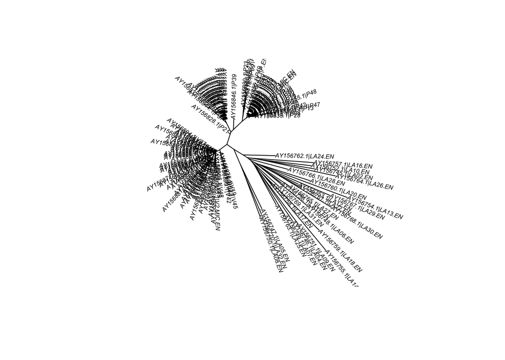

```r
if (!is.rooted(tree_env_NJ_TN93)) {
    ape::plot.phylo(tree_env_NJ_TN93, type = "unrooted", cex=0.5, lab4ut = "axial")
}
```

We assume the outgroup is `AY156745.1|LA02.EN` (one of the community sequences) and root the neighbour-joining tree on it, before plotting the rooted tree.

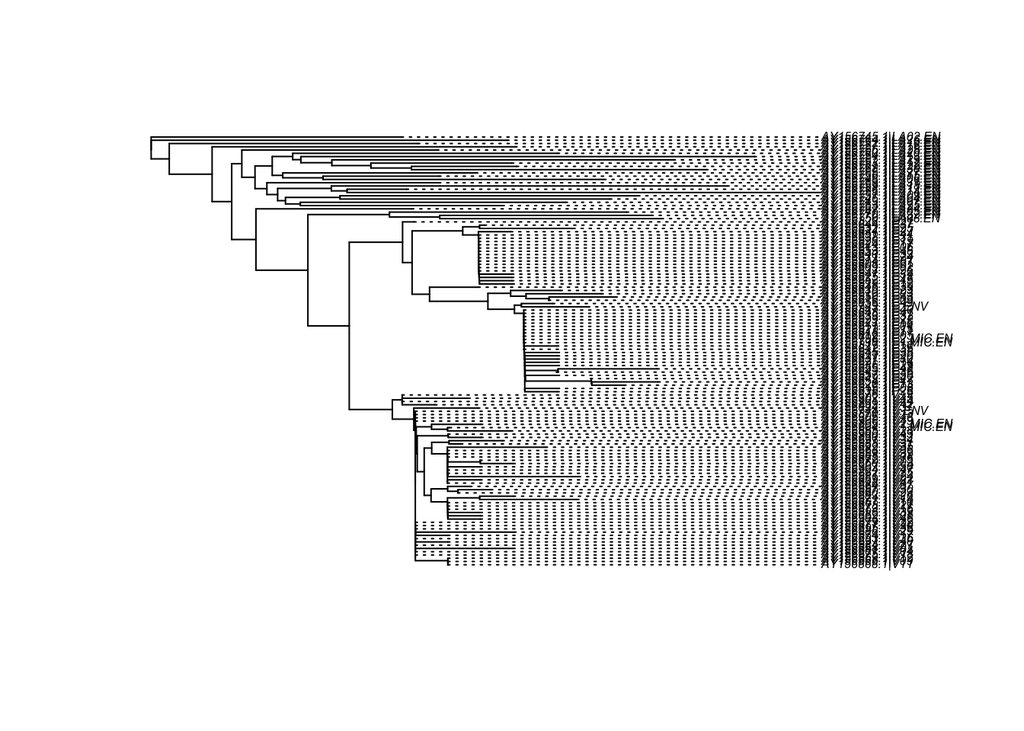

```r
  tree_env_NJ_TN93_rooted <- root.phylo(tree_env_NJ_TN93,
                                        outgroup = "AY156745.1|LA02.EN",
                                        resolve.root = TRUE)
  plot.phylo(tree_env_NJ_TN93_rooted, align.tip.label = TRUE, cex=0.5)
```

Now create a colour array to colour patient, victim and community sequences differently using the `tip.color` argument in `plot.phylo()`.

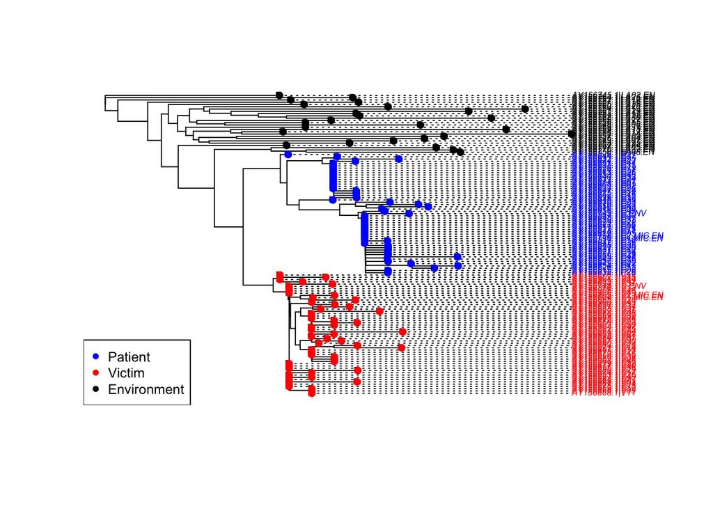

```r
    colours <- rep("black", length(allpatients_env))
    colours[match(patient_env, tree_env_NJ_TN93_rooted$tip.label)] <- 'blue'
    colours[match(victim_env, tree_env_NJ_TN93_rooted$tip.label)] <- 'red'

    plot.phylo(tree_env_NJ_TN93_rooted, align.tip.label = TRUE, cex=0.5,
               tip.color = colours)
    tiplabels(NA, pch=16, col=colours)
    legend("bottomleft", legend=c("Patient", "Victim", "Environment"),
           col=c("blue", "red", "black"), pch=16, cex=0.8)
```

Build the neighbour-joining tree using a Jukes-Cantor model, plot the tree and then plot the tanglegram connecting the Jukes Cantor NJ tree to the TN93 NJ tree.

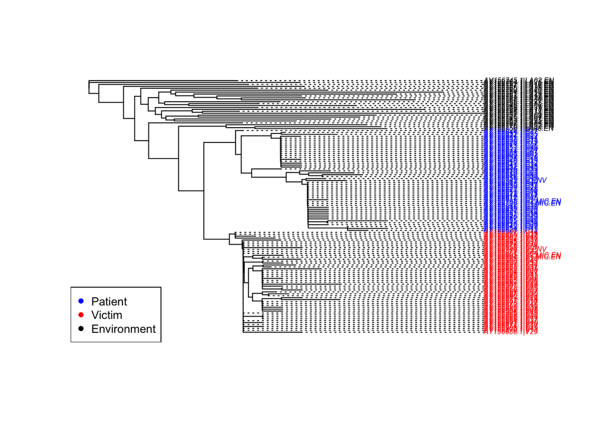

```r
# Construct and root Neighbour-joining tree
D_env_JC <- ape::dist.dna(env, model="JC", as.matrix=TRUE)
tree_env_NJ_JC <- phangorn::NJ(D_env_JC)
tree_env_NJ_JC_rooted <- root.phylo(tree_env_NJ_JC,
                                    outgroup = "AY156745.1|LA02.EN",
                                    resolve.root = TRUE)

# Plot the tree
plot.phylo(tree_env_NJ_JC_rooted, align.tip.label = TRUE, cex=0.5,
           tip.color = colours)
legend("bottomleft", legend=c("Patient", "Victim", "Environment"),
           col=c("blue", "red", "black"), pch=16, cex=0.8)
```

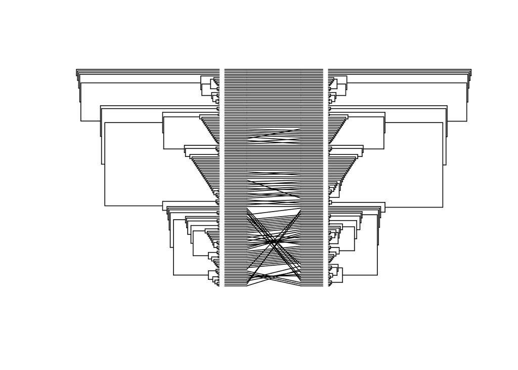

```r
# Plot the tanglegram
cophyloplot(tree_env_NJ_JC_rooted, tree_env_NJ_TN93_rooted, assoc=cbind(tree_env_NJ_JC_rooted$tip.label, tree_env_NJ_TN93_rooted$tip.label), show.tip.label = FALSE, space=100, gap =5, length.line=0.2)
```

## Parsimony

Calculate the parsimony score of the NJ tree. To use the function we have to first convert the alignment to an object of type `phyDat`, which is used by the `phangorn` package.

```r
  env_phyDat <- as.phyDat(env)
  parsimony(tree_env_NJ_JC, env_phyDat)
```

```
## [1] 1739
```

Now use the `pratchet()` function to find the maximum parsimony tree and then use `acctran()` to adjust the branch lengths, and again plot the tree.

```r
  # Calculate the maximum parsimony tree
  tree_env_MP <- pratchet(env_phyDat)
```

```
## Parsimony score of initial tree: 1612
## Iteration: 10. Best parsimony score so far: 1612Iteration: 20. Best parsimony score so far: 1611Iteration: 30. Best parsimony score so far: 1610Iteration: 40. Best parsimony score so far: 1609Iteration: 50. Best parsimony score so far: 1609Iteration: 60. Best parsimony score so far: 1609Iteration…
```

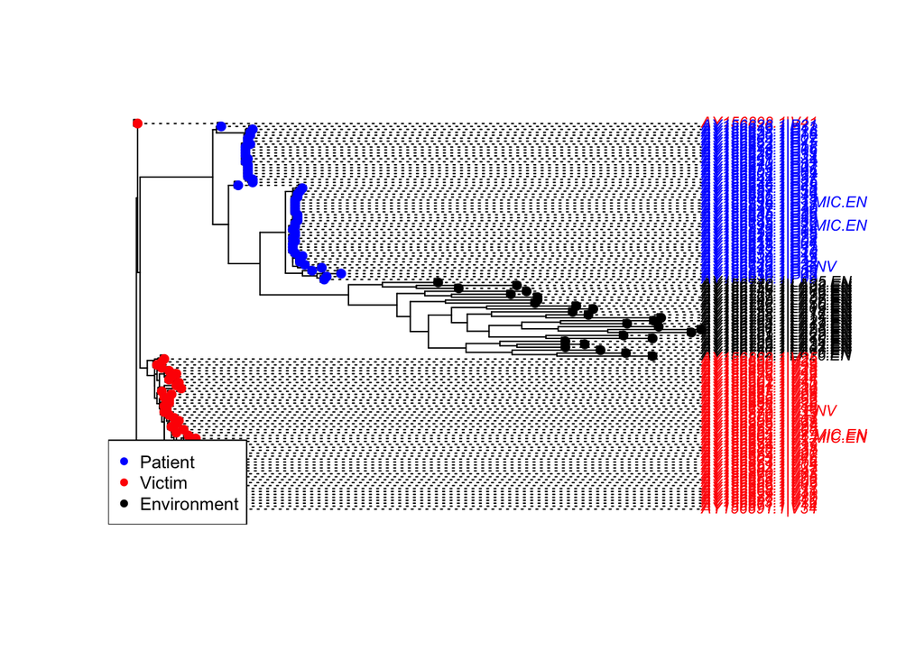

```r
  tree_env_MP <- acctran(tree_env_MP, data = env_phyDat)

  # Plot it
  colours <- rep("black", length(tree_env_MP$tip.label))
  colours[match(patient_env, tree_env_MP$tip.label)] <- 'blue'
  colours[match(victim_env, tree_env_MP$tip.label)] <- 'red'

  plot.phylo(tree_env_MP, align.tip.label = TRUE, cex=0.7,
               tip.color = colours)
  tiplabels(NA, pch=16, col=colours)
  legend("bottomleft", legend=c("Patient", "Victim", "Environment"),
       col=c("blue", "red", "black"), pch=16, cex=0.8)
```

We can also verify that the maximum parsimony tree has a lower parsimony score than the NJ tree.

```r
  parsimony(tree_env_NJ_TN93, env_phyDat)
```

```
## [1] 1743
```

```r
  parsimony(tree_env_MP, env_phyDat)
```

```
## [1] 1607
```

```r
  parsimony(tree_env_NJ_TN93, env_phyDat) < parsimony(tree_env_MP, env_phyDat)
```

```
## [1] FALSE
```

Now we plot the tanglegram comparing the neighbour-joining tree to the maximum parsimony tree.

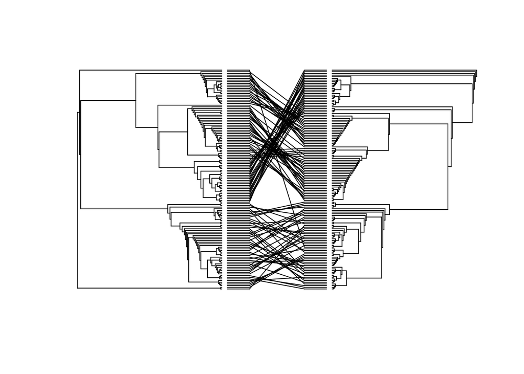

```r
  # Plot the tanglegram
  cophyloplot(tree_env_MP, tree_env_NJ_TN93_rooted,
              assoc=cbind(tree_env_MP$tip.label,
                          tree_env_NJ_TN93_rooted$tip.label),
              show.tip.label = FALSE, space=100, gap =5, length.line=0.1)
```

## Maximum-likelihood

Calculate the maximum-likelihood tree using the GTR model. Since the tree is unrooted (check it!) also root it on the same outgroup.

```r
  tree_env_ML_GTR <- pml_bb(env, model="GTR")
```

```
## optimize edge weights:  -10172.81 --> -10106.88
## optimize rate matrix:  -10106.88 --> -9779.706
## optimize edge weights:  -9779.706 --> -9779.158
## optimize topology:  -9779.158 --> -9772.674  NNI moves:  6
## optimize rate matrix:  -9772.674 --> -9772.645
## optimize edge weights:  -9772.645 --> -9772.645
## optimize topology:  -9772.645 --> -9772.645  NNI moves:  0
## optimize topology:  -10431.43 --> -9978.751  NNI moves:  38
## Ratchet iteration  1 , best pscore so far: -9772.645
## optimize topology:  -10247.76 --> -9772.324  NNI moves:  37
## Ratchet iteration  2 , best pscore so far: -9772.324
## optimize topology:  -10187.5 --> -9809.442  NNI moves:  27
## Ratchet iteration  3 , best pscore so far: -9772.324
## optimize topology:  -10034.39 --> -9771.961  NNI moves:  29
## Ratchet iteration  4 , best pscore so far: -9771.961
## optimize topology:  -10222.05 --> -9780.666  NNI moves:  28
## Ratchet iteration  5 , best pscore so far: -9771.961
## optimize topology:  -10338 --> -9806.958  NNI moves:  33
## Ratchet iteration  6 , best pscore so far: -9771.961
## optimize topology:  -10366.96 --> -9797.203  NNI moves:  38
## Ratchet iteration  7 , best pscore so far: -9771.961
## optimize topology:  -10273.57 --> -9774.959  NNI moves:  42
## Ratchet iteration  8 , best pscore so far: -9771.961
## optimize topology:  -10250.29 --> -9770.058  NNI moves:  36
## Ratchet iteration  9 , best pscore so far: -9770.058
## optimize topology:  -9999.463 --> -9783.162  NNI moves:  35
## Ratchet iteration  10 , best pscore so far: -9770.058
## optimize topology:  -10051.67 --> -9773.99  NNI moves:  33
## Ratchet iteration  11 , best pscore so far: -9770.058
## optimize topology:  -10015.36 --> -9778.301  NNI moves:  31
## Ratchet iteration  12 , best pscore so far: -9770.058
## optimize topology:  -10432.51 --> -9925.551  NNI moves:  41
## Ratchet iteration  13 , best pscore so far: -9770.058
## optimize topology:  -10216.37 --> -9778.796  NNI moves:  36
## Ratchet iteration  14 , best pscore so far: -9770.058
## optimize topology:  -10009.7 --> -9785.658  NNI moves:  23
## Ratchet iteration  15 , best pscore so far: -9770.058
## optimize topology:  -10084.73 --> -9799.319  NNI moves:  34
## Ratchet iteration  16 , best pscore so far: -9770.058
## optimize topology:  -9994.7 --> -9790.024  NNI moves:  36
```

[output cut: 173 more lines]

```
## optimize topology:  -10257.89 --> -9768.516  NNI moves:  37
## Ratchet iteration  104 , best pscore so far: -9755.506
## optimize topology:  -10178.23 --> -9838.195  NNI moves:  34
## Ratchet iteration  105 , best pscore so far: -9755.506
## optimize topology:  -10278.16 --> -9755.506  NNI moves:  31
## Ratchet iteration  106 , best pscore so far: -9755.506
## optimize topology:  -10023.13 --> -9767.204  NNI moves:  24
## Ratchet iteration  107 , best pscore so far: -9755.506
## optimize topology:  -9961.169 --> -9775.99  NNI moves:  31
## Ratchet iteration  108 , best pscore so far: -9755.506
## optimize rate matrix:  -9755.506 --> -9755.468
## optimize edge weights:  -9755.468 --> -9755.468
## optimize topology:  -9755.468 --> -9755.468  NNI moves:  0
## optimize rate matrix:  -9755.468 --> -9755.468
## optimize edge weights:  -9755.468 --> -9755.468
```

```r
  tree_env_ML_GTR_rooted <- root.phylo(tree_env_ML_GTR$tree,
                                       outgroup = "AY156745.1|LA02.EN",
                                       resolve.root = TRUE)
```

Now plot the ML tree.

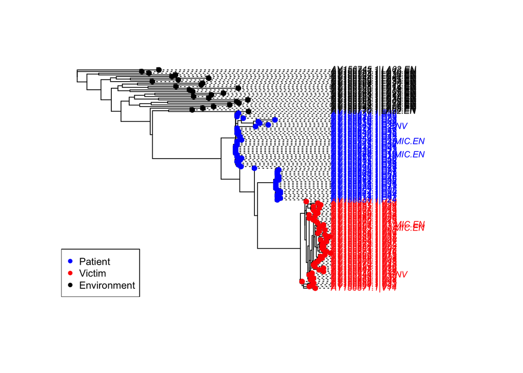

```r
  colours <- rep("black", length(tree_env_ML_GTR_rooted$tip.label))
  colours[match(patient_env, tree_env_ML_GTR_rooted$tip.label)] <- 'blue'
  colours[match(victim_env, tree_env_ML_GTR_rooted$tip.label)] <- 'red'

  plot.phylo(tree_env_ML_GTR_rooted, align.tip.label = TRUE, cex=0.7,
               tip.color = colours)
  tiplabels(NA, pch=16, col=colours)
  legend("bottomleft", legend=c("Patient", "Victim", "Environment"),
       col=c("blue", "red", "black"), pch=16, cex=0.8)
```

Tanglegram between the NJ and ML trees

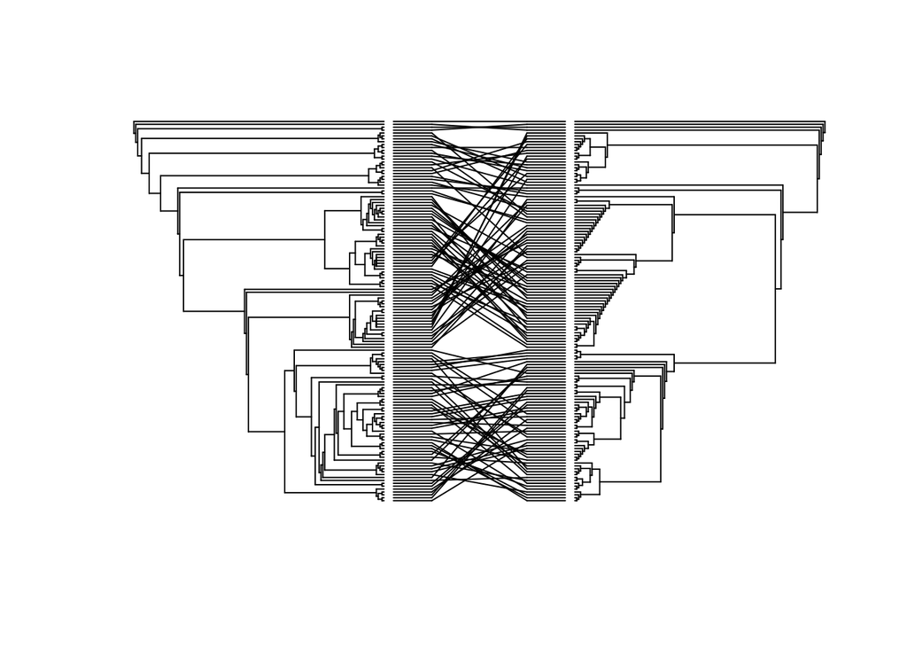

```r
  # Plot the tanglegram
  cophyloplot(tree_env_ML_GTR_rooted, tree_env_NJ_TN93_rooted,
              assoc=cbind(tree_env_ML_GTR_rooted$tip.label,
                          tree_env_NJ_TN93_rooted$tip.label),
              show.tip.label = FALSE, space=100, gap =5, length.line=0.1)
```